# Metaphors for 2026

Planning for Metropolitan Change

Rachel Franklin (@rsfrankl)

Center for Geographic Analysis | Harvard University

2026-06-23

# Anyone who believes that exponential growth can go on forever in a finite world is either a madman or an economist.

—Kenneth Boulding

# 1. A rising tide lifts all boats MPOs

## We’re accustomed to uneven growth in a wider context of expansion. We’re about to find out what happens when the tide goes out.

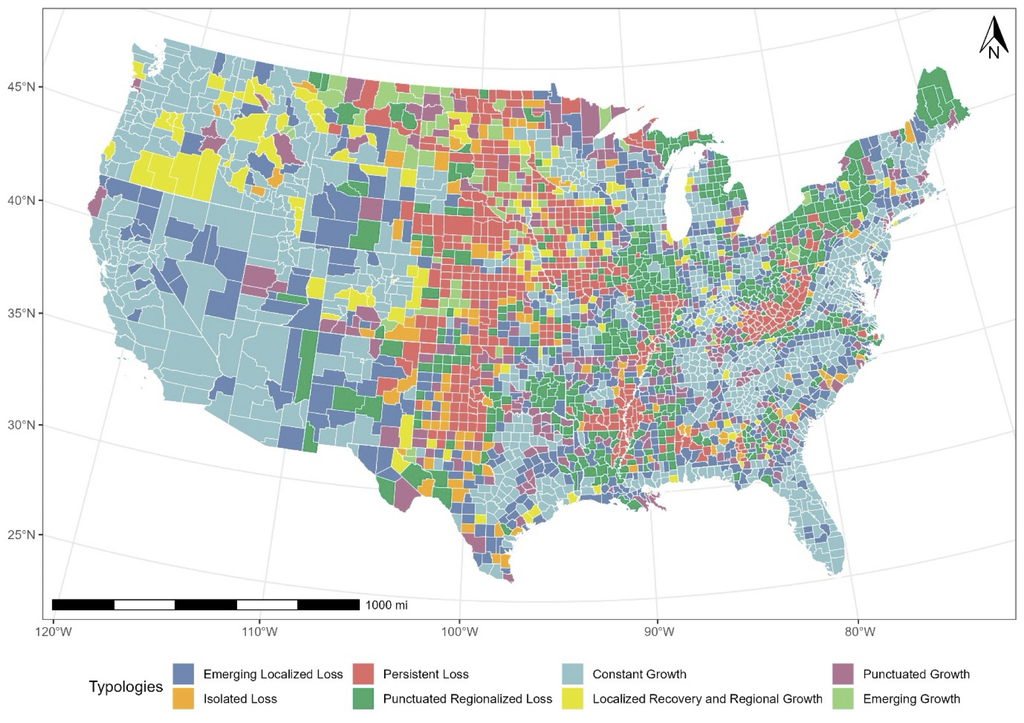

Categories of US Population Change, 1950–2020

Park, Seymour, and Franklin. (forthcoming). “Characterizing the Landscape of Loss: A Spatio-Temporal Contextual Approach to Measuring U.S. County-Level Depopulation,” Annals of the American Association of Geographers

# 2. Siphons

(imagine a giant—spatially and demographically distributed—sucking sound)

## One area’s gains are another’s loss.

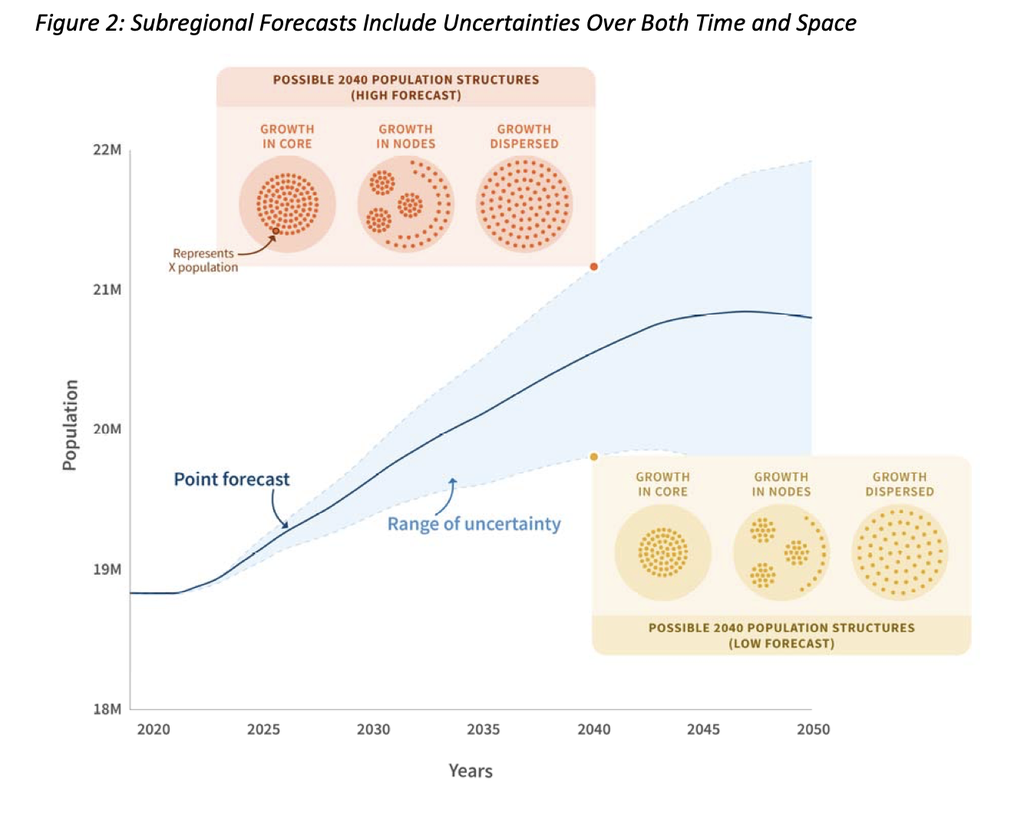

SCAG Technical Working Group, January, 2023

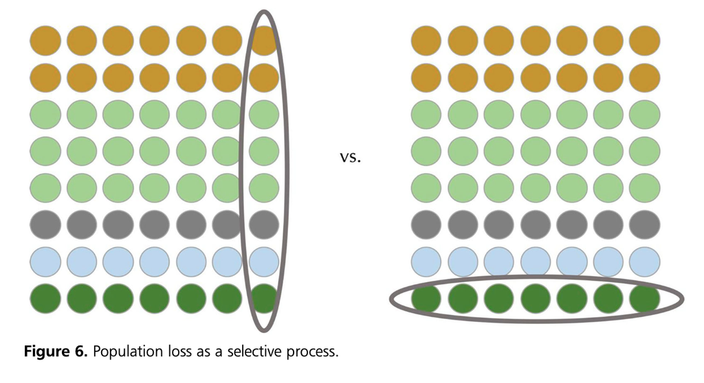

Rachel S. Franklin (2020): I come to bury (population) growth, not to praise it, *Spatial Economic Analysis*, DOI: 10.1080/17421772.2020.1802056

## What happens when there’s nothing left to siphon?

# 3. [Cloudy] crystal balls

## Predicting the future is easier when nothing is changing much.

## Harder when the wider policy landscape is unpredictable.

# 4. Magnets

## Relying on place characteristics to attract other places’s people (and reproductive potential)

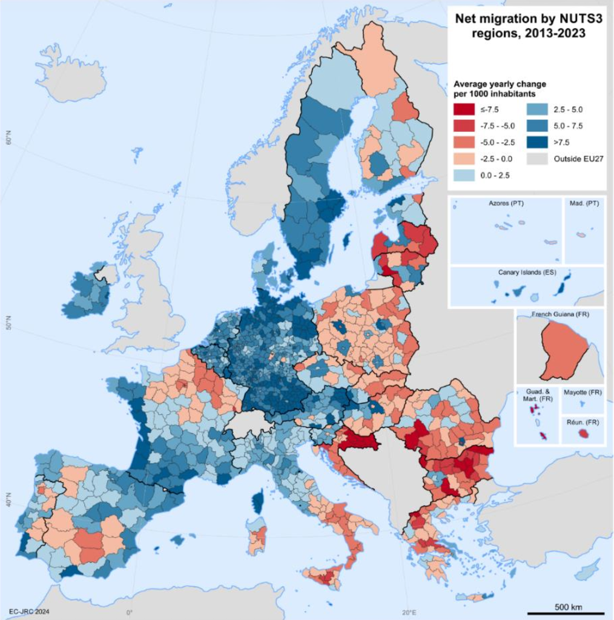

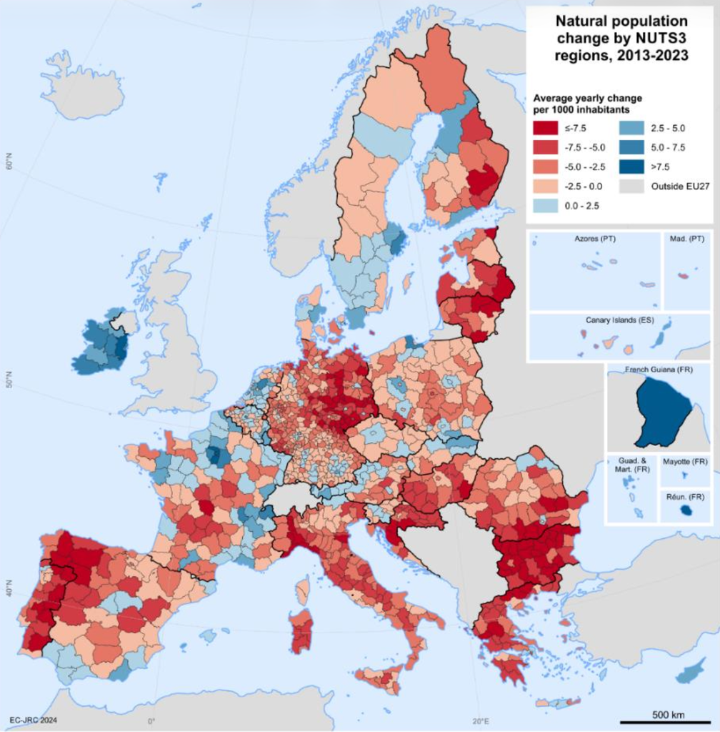

TESTORI, G., FRANKLIN, R., SARACENO, P., PERTOLDI, M., PEREA MILLA FERNANDEZ, D. et al., Territories and demographic change - Regional patterns and policy approaches, Publications Office of the European Union, Luxembourg, 2026, https://data.europa.eu/doi/10.2760/4140574, JRC143332.

# 5. Balance Sheets

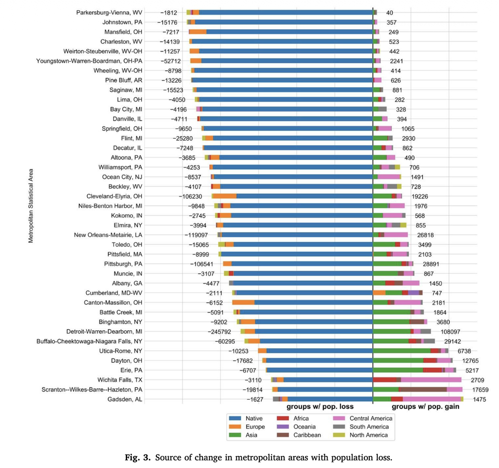

Between 2000 and 2012–2016

Bagchi-Sen, S., Franklin, R. S., Rogerson, P., & Seymour, E. (2020). Urban inequality and the demographic transformation of shrinking cities: The role of the foreign born. Applied Geography, 116, 102168.

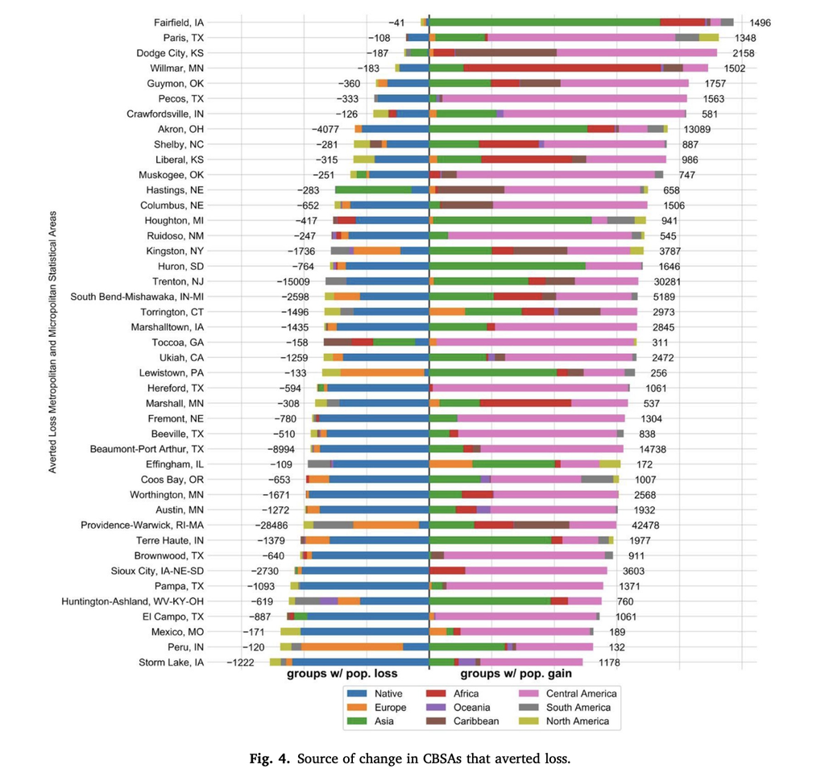

Between 2000 and 2012–2016

Bagchi-Sen, S., Franklin, R. S., Rogerson, P., & Seymour, E. (2020). Urban inequality and the demographic transformation of shrinking cities: The role of the foreign born. Applied Geography, 116, 102168.

# 6. World Cup

## Challenging the premise that, to grow, all that is required is to beat everyone else.

## Immediate takeaways

- Aging
- Below-replacement level fertility
- Housing challenges that don’t evaporate with decline
- Transport demand might not either
- Regional and global interdependence
- Uncertainty